# Homework #6

Andrea Astudillo

2024-10-26

```r
insurance = read.csv(file.choose())
library(readr)
library(fpp)
library(fpp2)
library(TTR)
insurance=(insurance)
insurance_ts=ts(insurance$Quotes, frequency = 12, start = c(2002,1), end = c(2005,4))
```

#2 Verify how much history to include in your analysis

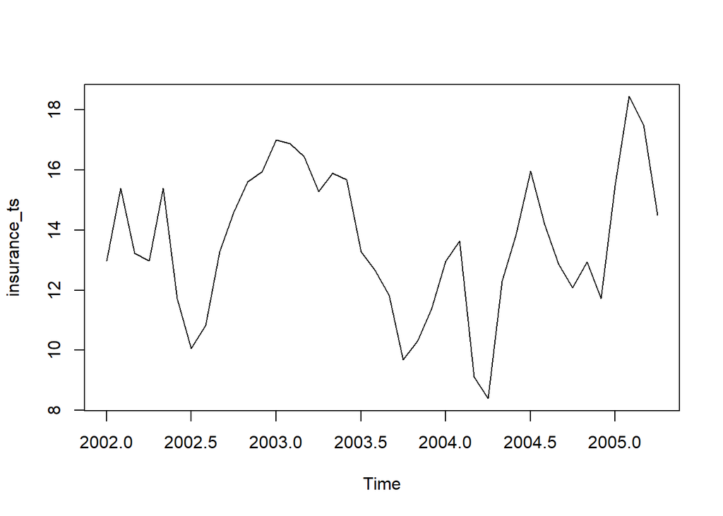

```r
plot(insurance_ts)
```

#3-Hypothesize if the dataset has trend, seasonality, or both

I hypothesize the data set will have both seasonality and trend.

#4 Verify using Acf

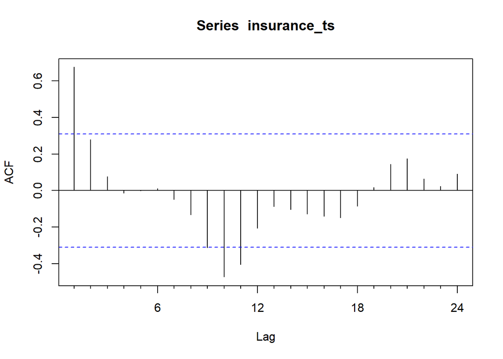

```r
Acf(insurance_ts)
```

The decomposition plot verifies what was explained in the Acf plot. The data contains seasonality and trends.

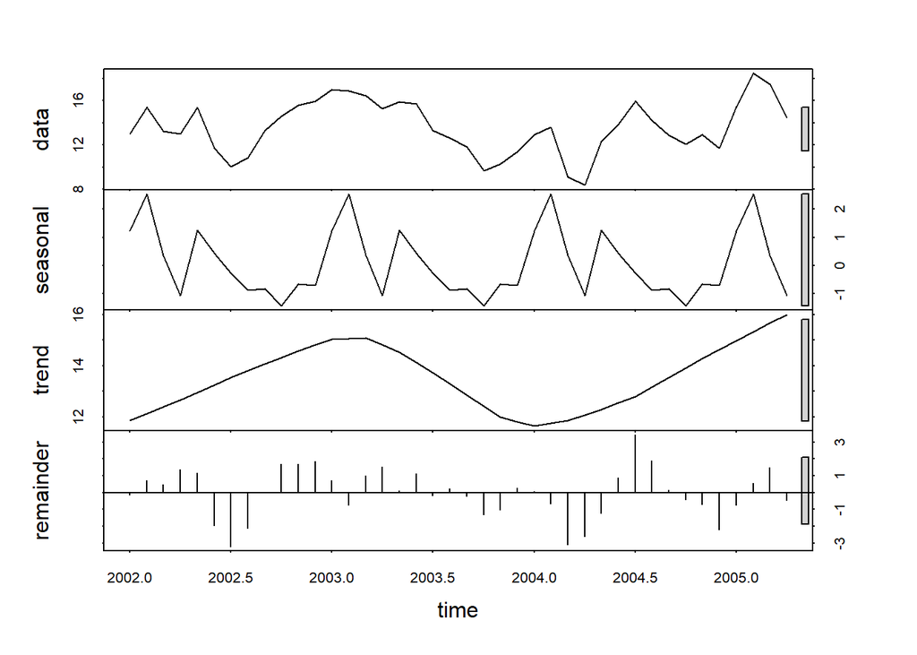

```r
stl_decomp = stl(insurance_ts,s.window = "periodic")
plot(stl_decomp)
```

#6. Chose an accuracy measure

I will choose the accuracy measure RMSE as it will penalize for less errors. We can observe in the data there are some years of increase and suddenly the following one a drop.

#7 Create a forecast model for the next 12 months. Include Naive, Average, Exponential Smoothing, HoltWinters, and Decomposition (both types).

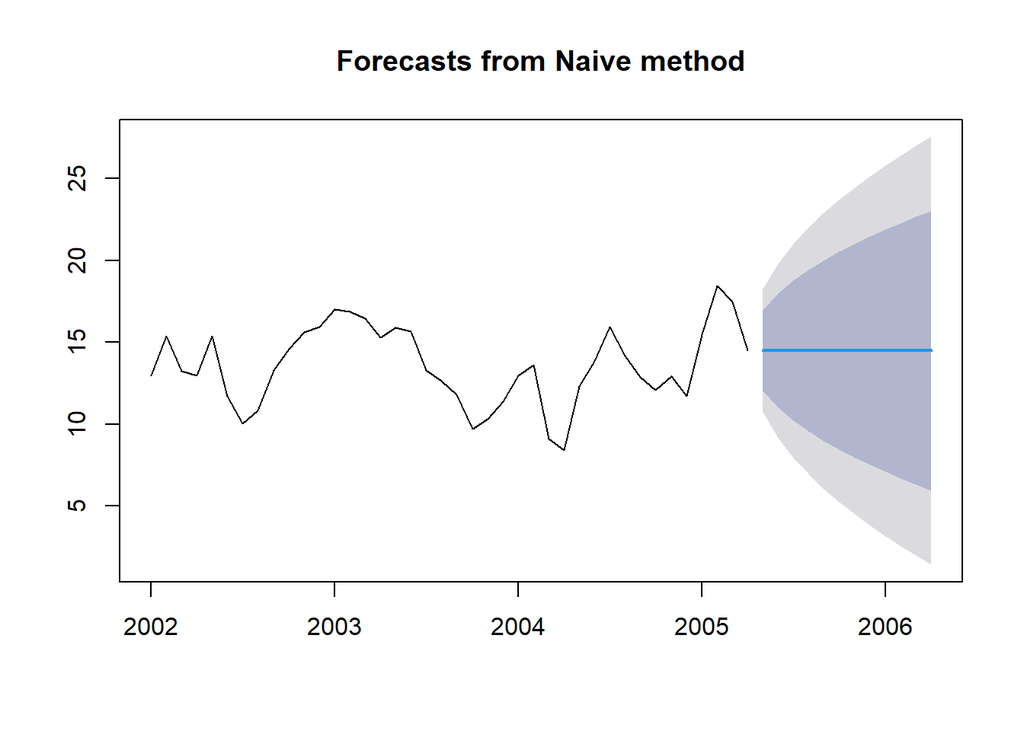

```r
naive_insurance=naive(insurance_ts,12)
forecast_naive=forecast(naive_insurance, h=12)
plot(forecast_naive)
```

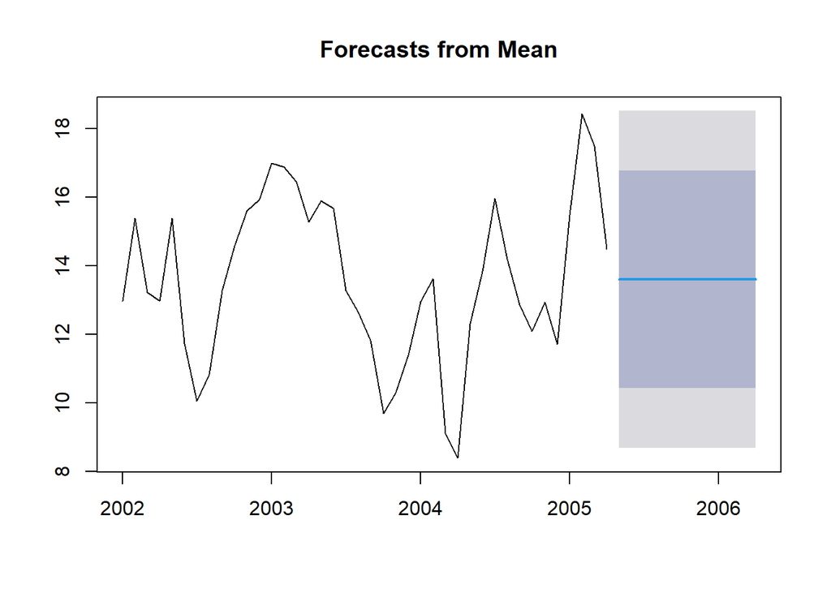

```r
mean_insurance=meanf(insurance_ts,12)
forecast_mean=forecast(mean_insurance, h=12)
plot(forecast_mean)
```

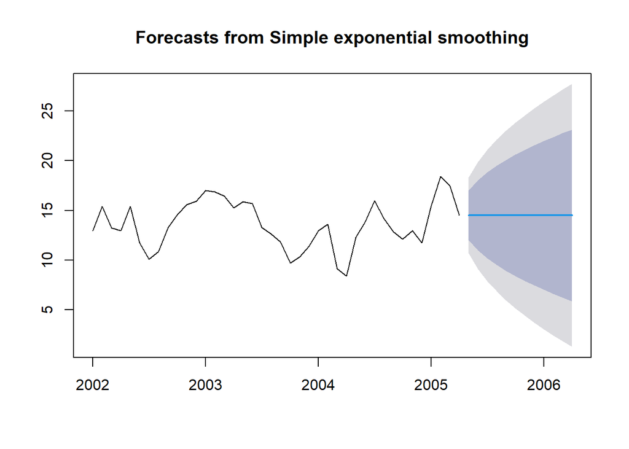

```r
ss_insurance=ses(insurance_ts,12)
forecast_ss=forecast(ss_insurance, h=12)
plot(forecast_ss)
```

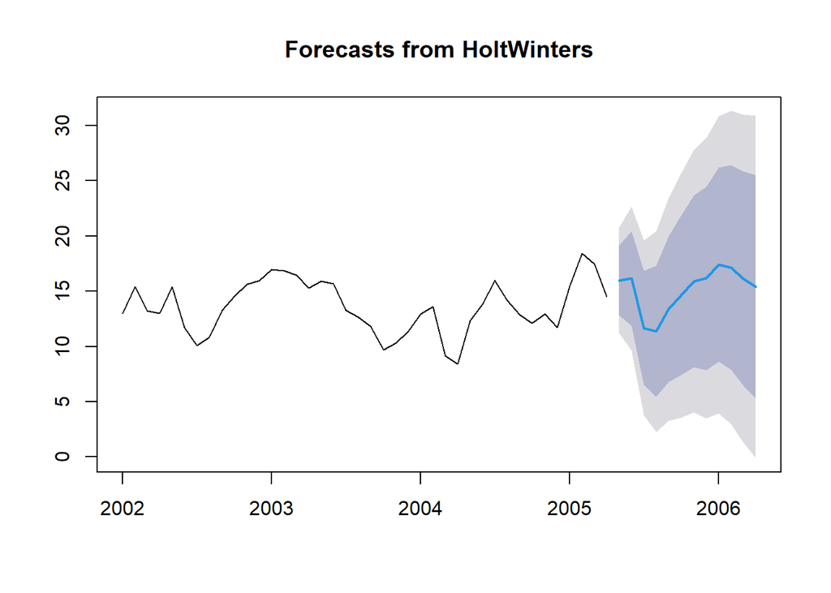

```r
hw_insurance=HoltWinters(insurance_ts)
forecast_hw=forecast(hw_insurance, h=12)
plot(forecast_hw)
```

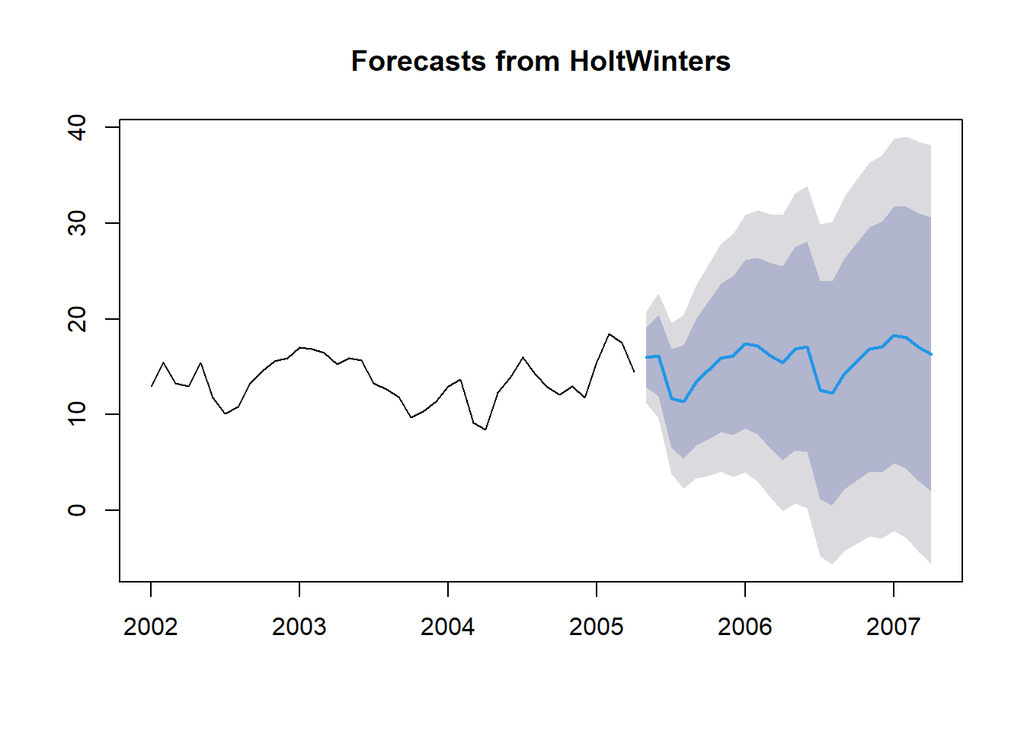

```r
decompose_insurance_additive=decompose(insurance_ts)
additive_insurance=HoltWinters(insurance_ts, seasonal = "additive")
forecast_additive=forecast(additive_insurance)
plot(forecast_additive)
```

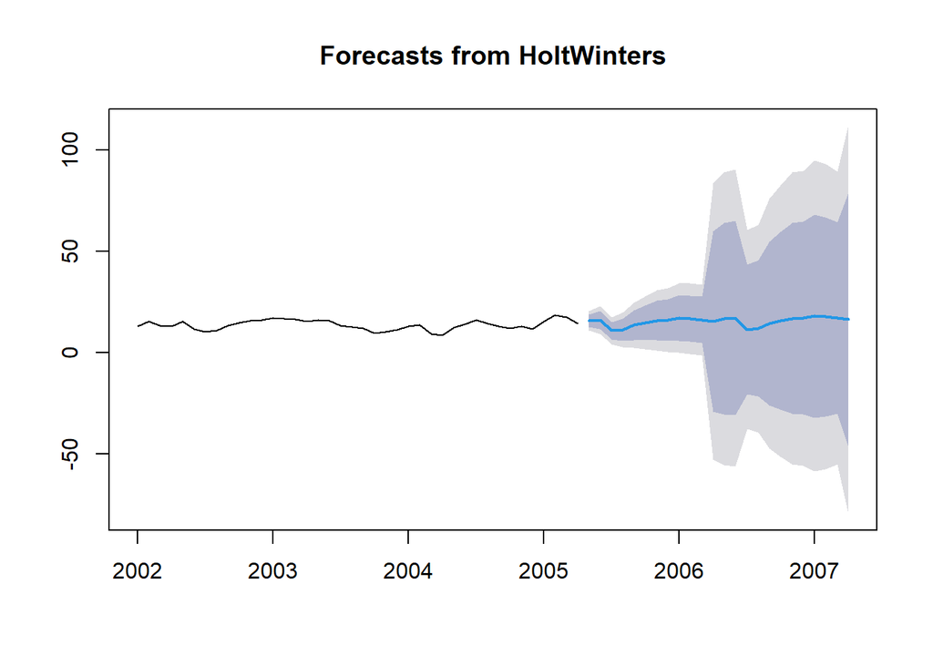

```r
decompose_insurance_multiplicative=decompose(insurance_ts, type = "multiplicative")
multiplicative_insurance=HoltWinters(insurance_ts, seasonal = "multiplicative")
forecast_multiplicative=forecast(multiplicative_insurance)
plot(forecast_multiplicative)
```

#8 Show model rank with accuracy measures

```r
naive_accuracy=accuracy(forecast_naive)
mean_accuracy=accuracy(forecast_mean)
ss_accuracy=accuracy(forecast_ss)
hw_accuracy=accuracy(forecast_hw)
additive_accuracy=accuracy(forecast_additive)
multiplicative_accuracy=accuracy(forecast_multiplicative)
table_accuracy=data.frame(Method=c("Naive", "Mean", "Exponential Smoothing", "Holt-Winters"), ME=c(naive_accuracy[1,"ME"], mean_accuracy[1,"ME"], ss_accuracy[1,"ME"], hw_accuracy[1,"ME"]), RMSE=c(naive_accuracy[1,"RMSE"], mean_accuracy[1,"RMSE"], ss_accuracy[1,"RMSE"], hw_accuracy[1,"RMSE"]), MAE=c(naive_accuracy[1,"MAE"], mean_accuracy[1,"MAE"], ss_accuracy[1,"MAE"], hw_accuracy[1,"MAE"]), MAPE=c(naive_accuracy[1,"MAPE"], mean_accuracy[1,"MAPE"], ss_accuracy[1,"MAPE"], hw_accuracy[1,"MAPE"]), MASE=c(naive_accuracy[1,"MASE"], mean_accuracy[1,"MASE"], ss_accuracy[1,"MASE"], hw_accuracy[1,"MASE"]))
print(table_accuracy)
```

```
##                  Method            ME     RMSE      MAE     MAPE      MASE
## 1                 Naive  3.900077e-02 1.924326 1.573449 12.16031 0.4584592
## 2                  Mean -7.106200e-16 2.369165 1.955772 15.38394 0.5698575
## 3 Exponential Smoothing  3.789375e-02 1.900140 1.534297 11.85775 0.4470514
## 4          Holt-Winters -5.575202e-02 2.404405 1.797806 13.89177 0.5238306
```

#9 Choose which models and how are you going to use them for Forecasting

#10 Provide the forecast for the next 12 months (point and range) and explain why you feel confident with these forecasts.

Exponential Smoothing appears to be the best model comparing to the other forecasting methods. When ploting Acf, the forecast shows some seasonality and trend values that still needs to be considered, requiring some improvement. However, the Exponential Smoothing includes the upper and lower values proving expected values for uncertainty.

```r
forecast_ss
```

```
##          Point Forecast     Lo 80    Hi 80     Lo 95    Hi 95
## May 2005       14.49198 11.993593 16.99037 10.671026 18.31293
## Jun 2005       14.49198 10.958903 18.02506  9.088606 19.89535
## Jul 2005       14.49198 10.164935 18.81903  7.874335 21.10962
## Aug 2005       14.49198  9.495580 19.48838  6.850646 22.13331
## Sep 2005       14.49198  8.905863 20.07810  5.948751 23.03521
## Oct 2005       14.49198  8.372716 20.61124  5.133373 23.85059
## Nov 2005       14.49198  7.882435 21.10153  4.383553 24.60041
## Dec 2005       14.49198  7.426092 21.55787  3.685637 25.29832
## Jan 2006       14.49198  6.997484 21.98648  3.030138 25.95382
## Feb 2006       14.49198  6.592097 22.39186  2.410151 26.57381
## Mar 2006       14.49198  6.206520 22.77744  1.820462 27.16350
## Apr 2006       14.49198  5.838106 23.14585  1.257021 27.72694
```

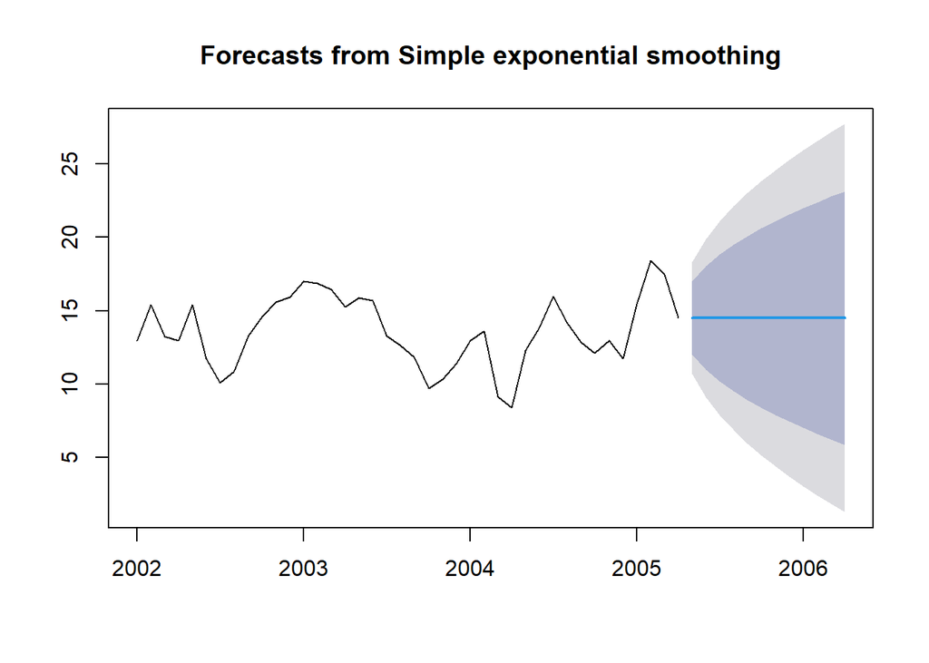

```r
plot(forecast_ss)
```

```r
attributes(forecast_ss)
```

```
## $names
##  [1] "model"     "mean"      "level"     "x"         "upper"     "lower"
##  [7] "fitted"    "method"    "series"    "residuals"
##
## $class
## [1] "forecast"
```

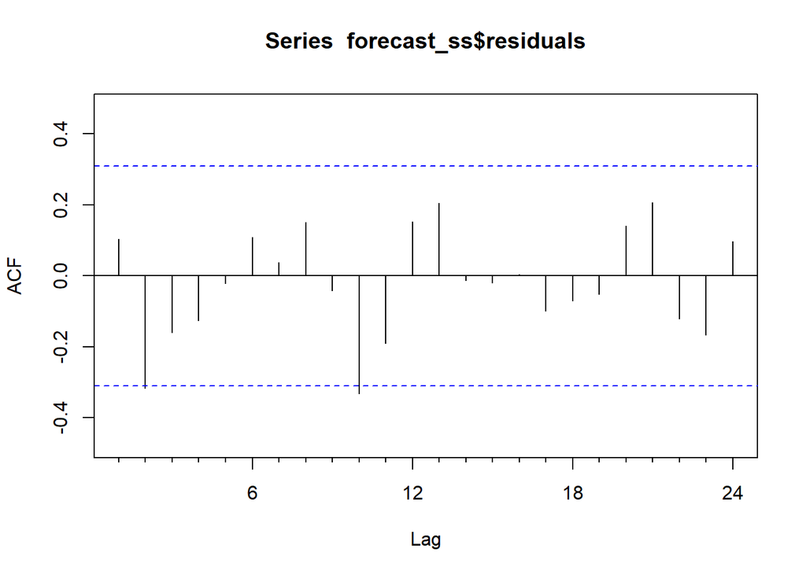

```r
Acf(forecast_ss$residuals)
```